# Análise Exploratória de Dados

Luiz Carlos Castro Cunha Junior

29/05/2021

[figure not shown]

## Estudo de Caso: Telecom

A base de dados traz informações dos clientes de uma telecom que cancelaram ou não sua conta.Durante a análise deverá ser respondida às seguintes questões de negócio:

- Quantos clientes a base de dados possui? Quantos são mulheres? E de forma relativa, quantas são mulheres?
- Quais são os valores da média, mediana, mínimo, máximo e quartis do tempo de relacionamento?
- Com base na distribuição de frequências do tempo de relacionamento, qual a proporção de clientes que ainda não completaram 1 ano de relacionamento?
- Qual a proporção de clientes que possuem 10 anos de relacionamento?
- Qual o % de clientes que têm 1 produto? E 2 produtos? Utilize a variável Num_de_Produtos.
- Qual o total de clientes que já cancelaram os produtos? E que não cancelaram? Qual a frequência relativa de cada categoria? Considere 1 para o cliente que cancelou e 0 para o cliente que não cancelou.

### Carregando os pacotes a serem utilizados

```r
library(tidyverse)
library(readxl)
library(rstatix)
library(moments)
library(knitr)
library(rmarkdown)
library(kableExtra)
library(emmeans)
library(htmltools)
library(dplyr)
library(questionr)
```

### Importando o Conjunto de Dados

```r
dataset<-readxl::read_xlsx("Exercícios.xlsx",
                           sheet = "Base de Dados 2")
```

### Visualizando o tipo de dados das variáveis

```r
str(dataset)
```

```
## tibble [10,000 x 5] (S3: tbl_df/tbl/data.frame)
##  $ ID                         : num [1:10000] 15634602 15647311 15619304 15701354 15737888 ...
##  $ Sexo                       : chr [1:10000] "Feminino" "Feminino" "Feminino" "Feminino" ...
##  $ Tempo_relacionamento (anos): num [1:10000] 2 1 8 1 2 4 10 5 7 9 ...
##  $ Num_de_Produtos            : num [1:10000] 1 1 3 2 1 4 2 2 2 2 ...
##  $ Cancelou                   : num [1:10000] 1 0 1 0 0 1 0 0 0 0 ...
```

## visualizando as primeiras linhas do Dataset

```r
kbl(dataset[1:5,2:5]) %>%
  kable_styling(bootstrap_options = c("striped", "hover"))
```

| Sexo | Tempo_relacionamento (anos) | Num_de_Produtos | Cancelou |
| --- | --- | --- | --- |
| Feminino | 2 | 1 | 1 |
| Feminino | 1 | 1 | 0 |
| Feminino | 8 | 3 | 1 |
| Feminino | 1 | 2 | 0 |
| Feminino | 2 | 1 | 0 |

### Perguntas de Negócio

> Quantos clientes a base de dados possui? Quantos são mulheres? E de forma relativa, quantas são mulheres?

```r
total_registros <- nrow(dataset)
names(total_registros) <-"Total de Clientes"

dfSexo <- data.frame(c(table(dataset$Sexo)[1],
             table(dataset$Sexo)[2],
             total_registros),
           c(prop.table(table(dataset$Sexo))[1] * 100,
             prop.table(table(dataset$Sexo))[2] * 100,
             prop.table(table(total_registros)))
           )
names(dfSexo) <- c("Quantidade", "Frequência")

kbl(dfSexo) %>%
  kable_styling(bootstrap_options = c("striped", "hover"))
```

|  | Quantidade | Frequência |
| --- | --- | --- |
| Feminino | 4543 | 45.43 |
| Masculino | 5457 | 54.57 |
| Total de Clientes | 10000 | 1.00 |

> Quais são os valores da média, mediana, mínimo, máximo e quartis do tempo de relacionamento?

```r
colnames(dataset)[3] <- "TempoRelacionamentoAnos"
indices <- c("Média", "Mediana", "Primerio Quartil", "Segundo Quartil", "Terceiro Quartil", "Intervalo Interquartil")

dfTempoRelacionalmento <-
              data.frame(
                c(
                    Média = mean(dataset$TempoRelacionamentoAnos),
                    Mediana =median(dataset$TempoRelacionamentoAnos),
                    PrimeiroQuartil = unname(quantile(dataset$TempoRelacionamentoAnos,0.25)),
                    SegundoQuartil  = unname(quantile(dataset$TempoRelacionamentoAnos, 0.50)),
                    TerceiroQuartil = unname(quantile(dataset$TempoRelacionamentoAnos, 0.75)),
                    IntervaloInterquartil = IQR(dataset$TempoRelacionamentoAnos)
                  ))
colnames(dfTempoRelacionalmento) <-"Resultdo"


kbl(dfTempoRelacionalmento) %>%
  kable_styling(bootstrap_options = c("striped", "hover"))
```

|  | Resultdo |
| --- | --- |
| Média | 5.0128 |
| Mediana | 5.0000 |
| PrimeiroQuartil | 3.0000 |
| SegundoQuartil | 5.0000 |
| TerceiroQuartil | 7.0000 |
| IntervaloInterquartil | 4.0000 |

> Com base na distribuição de frequências do tempo de relacionamento, qual a proporção de clientes que ainda não completaram 1 ano de relacionamento?
- 4.1 % dos clientes não completaram 1 ano de relacionamento.

> Qual a proporção de clientes que possuem 10 anos de relacionamento?
- 4.9 % dos clientes possuem 10 anos de relacionamento.

```r
dataset$TempoRelacionamentoAnos<-
  ifelse(dataset$TempoRelacionamentoAnos > 0,paste(dataset$TempoRelacionamentoAnos, " Anos"),"Não completou 1 Ano")


dfTabelaFrequenciaTempoRelacionamento <- questionr::freq(dataset$TempoRelacionamentoAnos,
                                         total = TRUE)

colnames(dfTabelaFrequenciaTempoRelacionamento) <- c("Frequência Relativa",
                                                     "Frequência Absoluta")

kbl(dfTabelaFrequenciaTempoRelacionamento[1:2]) %>%
    kable_styling(bootstrap_options = c("striped", "hover"))
```

|  | Frequência Relativa | Frequência Absoluta |
| --- | --- | --- |
| 1 Anos | 1035 | 10.3 |
| 10 Anos | 490 | 4.9 |
| 2 Anos | 1048 | 10.5 |
| 3 Anos | 1009 | 10.1 |
| 4 Anos | 989 | 9.9 |
| 5 Anos | 1012 | 10.1 |
| 6 Anos | 967 | 9.7 |
| 7 Anos | 1028 | 10.3 |
| 8 Anos | 1025 | 10.2 |
| 9 Anos | 984 | 9.8 |
| Não completou 1 Ano | 413 | 4.1 |
| Total | 10000 | 100.0 |

> Qual o % de clientes que têm 1 produto? E 2 produtos?

Podemos observar na tabela abaixo que 96,7% dos clientes possuem entre 1 e 2 produtos.

Sendo que:

- Para 1 Produto 50.8% dos Clientes
- Para 2 Produtos 45.9% dos Clientes

```r
dfTabelaFrequenciaClientes <- questionr::freq(dataset$Num_de_Produtos,total = TRUE)

colnames(dfTabelaFrequenciaClientes) <- c("FrequênciaRelativa",
                                                     "Frequência Absoluta")
rownames(dfTabelaFrequenciaClientes)[1:4] <-
  paste(rownames(dfTabelaFrequenciaClientes)[1:4], "Produtos")

kbl(dfTabelaFrequenciaClientes[1:2]) %>%
    kable_styling(bootstrap_options = c("striped", "hover"))
```

|  | FrequênciaRelativa | Frequência Absoluta |
| --- | --- | --- |
| 1 Produtos | 5084 | 50.8 |
| 2 Produtos | 4590 | 45.9 |
| 3 Produtos | 266 | 2.7 |
| 4 Produtos | 60 | 0.6 |
| Total | 10000 | 100.0 |

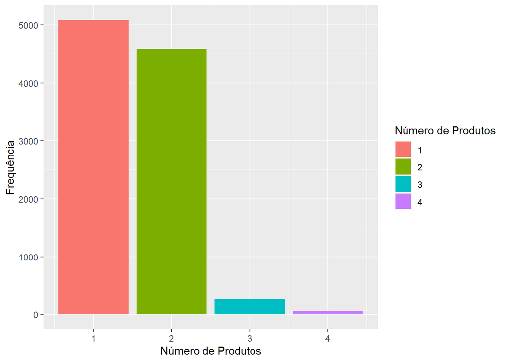

```r
dataset %>%
  ggplot(aes(dataset$Num_de_Produtos, fill = as.factor(dataset$Num_de_Produtos))) +
  geom_bar(stat = "count")  +
  labs(fill = "Número de Produtos")+
  xlab("Número de Produtos") +
  ylab("Frequência")
```

> Qual o total de clientes que já cancelaram os produtos? E que não cancelaram?

2037 cancelaram seus produtos e 7963 não cancelaram seus produtos.

> Qual a frequência relativa de cada categoria? Considere 1 para o cliente que cancelou e 0 para o cliente que não cancelou.

```r
View(ifelse(dataset$Cancelou ==0, "Cancelou",dataset$Cancelou))

dataset$Cancelou <- ifelse(dataset$Cancelou ==0, "Não Cancelou",dataset$Cancelou)
dataset$Cancelou <- ifelse(dataset$Cancelou ==1, "Cancelou",dataset$Cancelou)

dfClientesCancelamento = questionr::freq(dataset$Cancelou, total = TRUE)
names(dfClientesCancelamento)<- c("Frequência_Relativa",
                                  "Frequência_Absoluta")

kbl(dfClientesCancelamento[1:2]) %>%
  kable_styling(bootstrap_options = c("striped", "hover"))
```

|  | Frequência_Relativa | Frequência_Absoluta |
| --- | --- | --- |
| Cancelou | 2037 | 20.4 |
| Não Cancelou | 7963 | 79.6 |
| Total | 10000 | 100.0 |

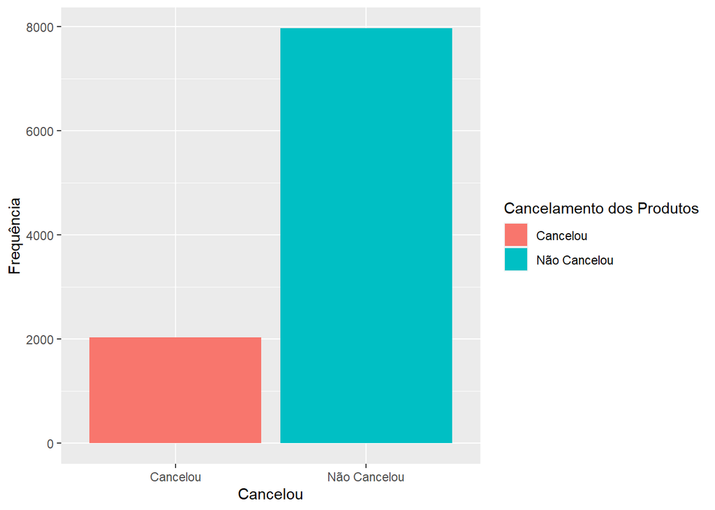

```r
dataset%>%
  ggplot(aes(Cancelou, fill = as.factor(Cancelou))) +
  geom_bar(stat = "count") +
  labs(fill = "Cancelamento dos Produtos")+
  ylab("Frequência")
```